# Examples of visualization

pmd

Import the necessary libraries:

```r
library(tidyverse)
library(here)
library(ndjson)
library(xslt)
library(fs)
library(ggplot2)
library(readxl)
library(tidytext)

require(readr)  # For read_csv()
require(purrr)  # For map(), reduce()

source(here("src/p017-functions.R"))
```

# Read in the data

Read in the data of plays converted to JSONL

```r
read_plays_jsonl(here("data")) %>% select(filename, everything()) -> plays
```

## Read in the excel sheet of characters and variations of character-names

```r
variants <- read_excel(here("data", "Rolleliste.xlsx")) %>%
     unnest_tokens(variant, Alias, token = "regex", pattern = ", ") %>%
    mutate(
      Karakter = tolower(Karakter),
      variant = tolower(variant)
    )
```

```
* `` -> ...4
```

Combine the plays and the excel sheet:

```r
plays %>%
  mutate(speaker = tolower(speaker)) %>%
  left_join(variants, by = c("filename"="Filnavn", "speaker"="variant")) %>%
  mutate(speaker = if_else(!is.na(Karakter), Karakter, speaker)) %>%
  distinct -> plays
```

# Visualization

Basically, we need to implement a function that does the following: `character_comparison_plot(<list of character names>, <list of character names>)`

```r
# Count words in "spoke"
plays %>%
  # Remove rows that are not dialogue and empty speakers
  filter(!is.na(spoke), speaker != "") %>%

  # Select only the columns, that we are interested in
  select(speaker, title, year, spoke) %>%

  # Add the number of spoken words
  mutate(n_spoken_words = str_count(spoke, '\\w+')) %>%
  # Remove the spoken words
  select(-spoke) %>%

  # Group by title and speaker
  group_by(title, year, speaker) %>%

  # Sum the words spoken by each speaker in each play
  # Lastly store the new data frame in a new reference for later use
    summarise(words = sum(n_spoken_words), title, year) %>%
    ##    ungroup() %>%
  distinct() -> summary
summary %>%
    ungroup(speaker) %>%
    summarise(words_play = sum(words)) -> totals
summary %>%
  full_join(totals) %>%
    summarise(freq = words / words_play, speaker, title, year, words, words_play) %>%
    ungroup() -> summary
summary
```

| title | year | speaker | freq | words | words_play |
| --- | --- | --- | --- | --- | --- |
| ARTAXERXES |  | . | 1.397713e-03 | 11 | 7870 |
| ARTAXERXES |  | arbaces | 2.390089e-01 | 1881 | 7870 |
| ARTAXERXES |  | artabanus | 2.236341e-01 | 1760 | 7870 |
| ARTAXERXES |  | artabanus og semira. | 1.270648e-04 | 1 | 7870 |
| ARTAXERXES |  | artaxerxes | 2.831004e-01 | 2228 | 7870 |
| ARTAXERXES |  | chorus | 4.066074e-03 | 32 | 7870 |
| ARTAXERXES |  | mandane | 1.391360e-01 | 1095 | 7870 |
| ARTAXERXES |  | semira | 1.095299e-01 | 862 | 7870 |
| Barselsstuen | (1724) | 1. advokat | 7.131223e-03 | 162 | 22717 |
| Barselsstuen | (1724) | 1. dame | 4.494431e-02 | 1021 | 22717 |

[output cut: 603 more lines]

```r
NA
```

## Comparison of individual characters

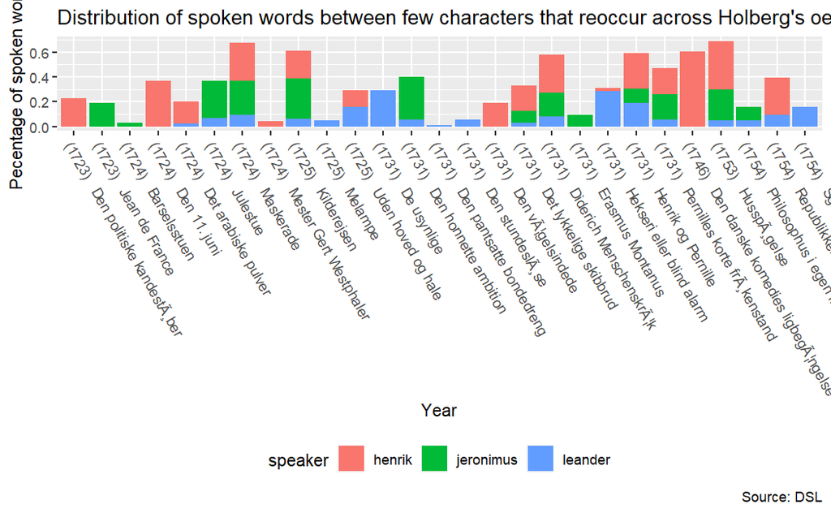

```r
  summary %>%
  #filter(speaker %in% c("henrik","pernille","troels")) %>%
  filter(speaker %in%   c("henrik", "jeronimus", "leander")) -> tmp
  #arrange(year) %>%

  # Below follow two possible ways of visualizing the comparison.

  # Add year to title
  tmp %>% mutate(title = paste(year," ",title)) %>%
  ggplot(aes(fill = speaker, y = freq, x = title)) +
    geom_bar(stat="identity") +
    theme(legend.position="bottom") +
    labs(
      title = "Distribution of spoken words between few characters that reoccur across Holberg's oeuvre by year of publication",
      caption = "Source: DSL"
    ) +
  xlab("Year") +
  ylab("Pecentage of spoken words") +
  theme(axis.text.x=element_text(angle = -60, hjust = 0))

      ggsave(here("graphs/pers-visualiseringer", "fordeling_talte_ord_v1.pdf"), width=16, height=9)
```

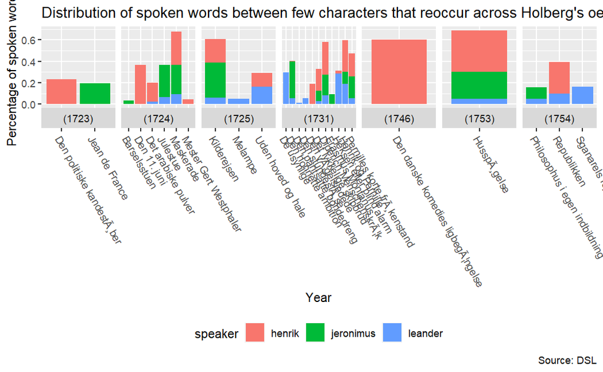

```r
  # We might also use year as a facet
  tmp %>%
  ggplot(aes(fill = speaker, y = freq, x = title)) +
    geom_bar(stat="identity") +
    theme(legend.position="bottom") +
    labs(
      title = "Distribution of spoken words between few characters that reoccur across Holberg's oeuvre by year of publication",
      caption = "Source: DSL"
    ) +
  xlab("Year") +
  ylab("Percentage of spoken words") +
  facet_wrap(~year, scales = 'free_x', ncol=nrow(summary), switch="x") +
  theme(axis.text.x=element_text(angle = -60, hjust = 0))
    ggsave(here("graphs/pers-visualiseringer", "fordeling_talte_ord_v2.pdf"), width=16, height=9)
```

## Comparison between groups of characters

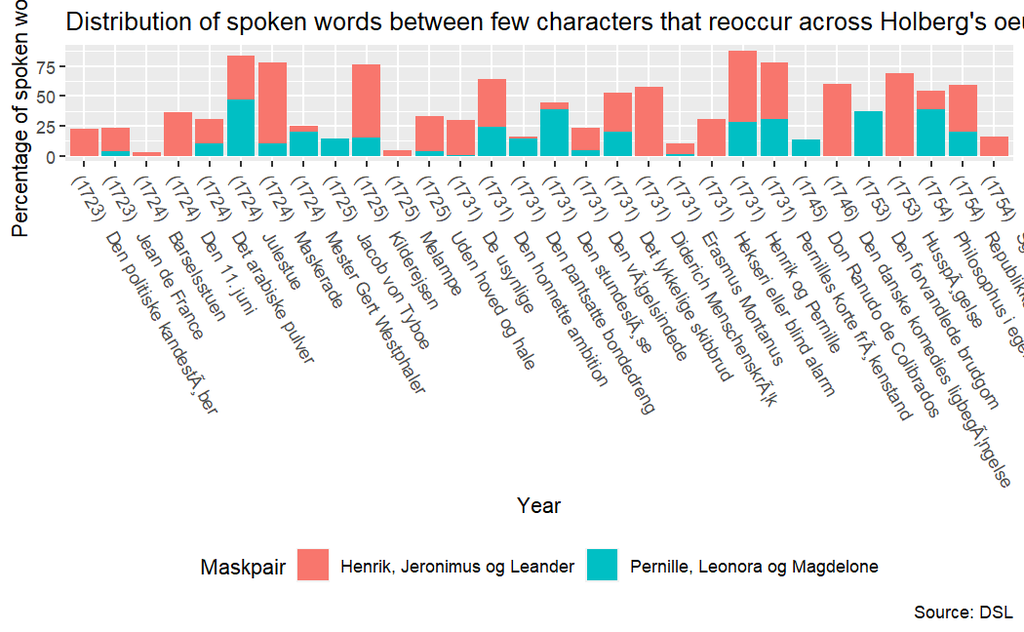

```r
group_1 <- c("henrik", "jeronimus", "leander")
group_2 <- c("pernille", "leonora", "magdelone")

summary %>%
  filter(speaker %in% c(group_1, group_2)) %>%
  mutate(gruppe = if_else(speaker %in% group_1, "Henrik, Jeronimus og Leander","Pernille, Leonora og Magdelone")) -> tmp2
  #filter(speaker %in% c("henrik","pernille","leonora")) %>%
  #arrange(year) %>%

  # Below follow two possible ways of visualizing the comparison.

  # Add year to title
  tmp2 %>% mutate(title = paste(year," ",title)) %>%
    ggplot(aes(fill = gruppe, y = freq*100, x = title)) +
    geom_bar(stat="identity") +
    theme(legend.position="bottom") +
    labs(
      title = "Distribution of spoken words between few characters that reoccur across Holberg's oeuvre by year of publication",
      caption = "Source: DSL"
    ) +
  xlab("Year") +
  ylab("Percentage of spoken words") +
  labs(fill='Maskpair') +
  theme(axis.text.x=element_text(angle = -60, hjust = 0))
        ggsave(here("graphs/pers-visualiseringer", "fordeling_talte_ord_grupper_v1.pdf"), width=16, height=9)
```

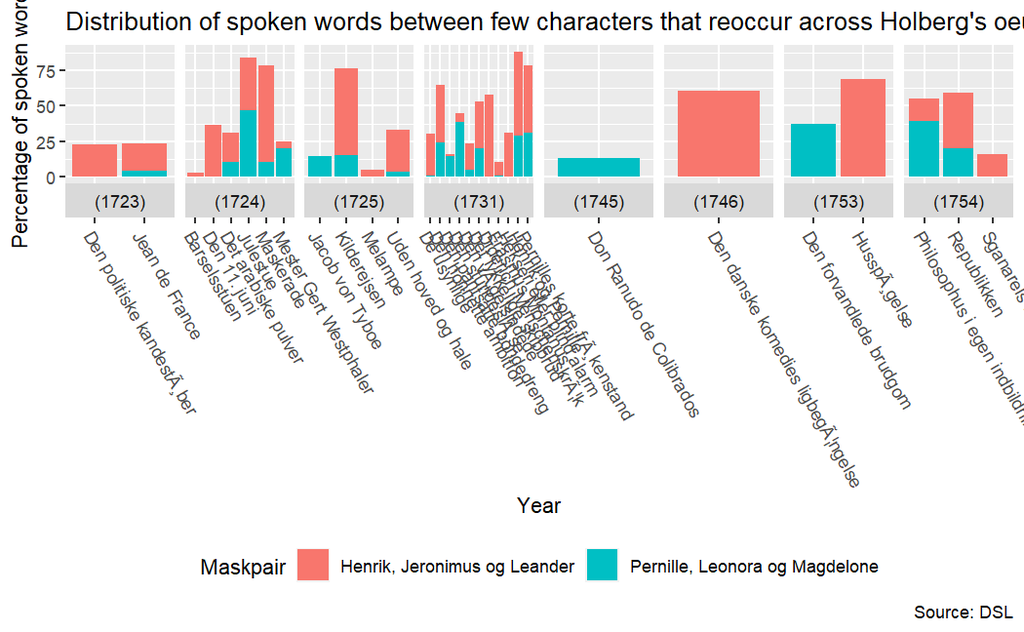

```r
  # We migt also use year as a facet
  tmp2 %>%
    ggplot(aes(fill = gruppe, y = freq*100, x = title)) +
    geom_bar(stat="identity") +
    theme(legend.position="bottom") +
    labs(
      title = "Distribution of spoken words between few characters that reoccur across Holberg's oeuvre by year of publication",
      caption = "Source: DSL"
    ) +
  xlab("Year") +
  ylab("Percentage of spoken words") +
  labs(fill='Maskpair') +
  facet_wrap(~year, scales = 'free_x', ncol=nrow(summary), switch="x") +
  theme(axis.text.x=element_text(angle = -60, hjust = 0))
        ggsave(here("graphs/pers-visualiseringer", "fordeling_talte_ord_grupper_v2.pdf"), width=16, height=9)
```

```r
NA
NA
```

## Sorting by year and/or title

In statistics, we work with something called a *factor*. A factor is a variable or an observation which may hold values that cannot be sorted, as numerical data can. A color, for example, cannot be sorted - yet if you take them as factors, you can assign them a sequence you want them to have.

We might use factors to sort the plays by title. First, we can make a list of all titles sorted by year of publication. Then we can transform the title-column to factor variables, and assign the sequence that they had when they were sorted by year.

```r
summary %>%
  filter(speaker %in%   c("henrik", "jeronimus", "leander")) %>%
  arrange(desc(year)) %>% # We sort the vertical axis by year (ascending)
  distinct(title) %>%
  pull(title) -> factor_levels_sort_year

summary %>%
  filter(speaker %in%   c("henrik", "jeronimus", "leander")) %>%
  distinct(title) %>%
  arrange(desc(title)) %>%  # We sort the vertical axis by title
  pull(title) -> factor_levels_sort_title

#summary$title_fct <- factor(summary$title, factor_levels)
```

## Sort by title

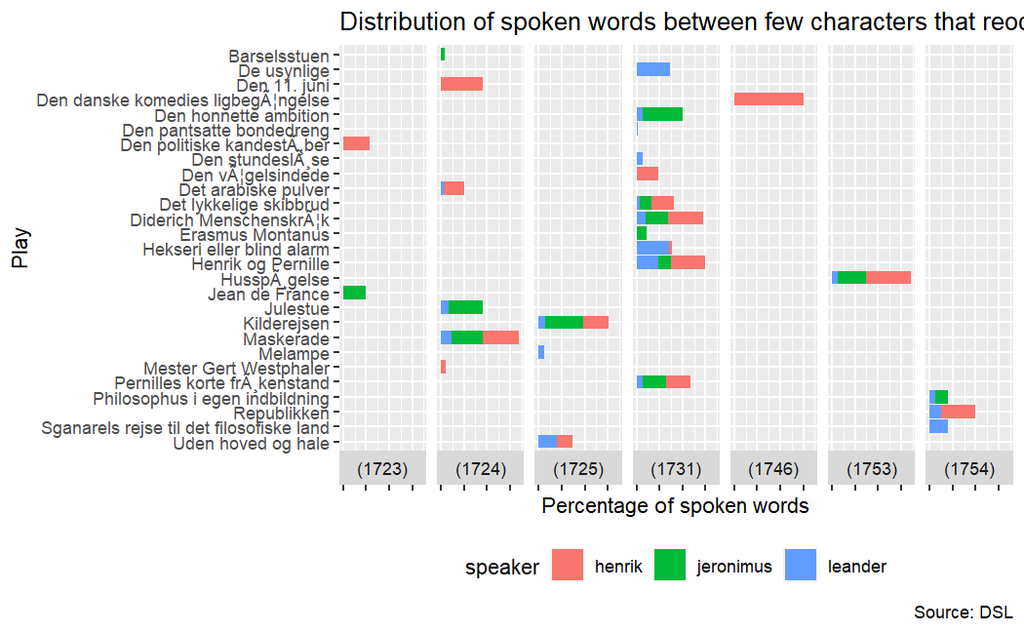

```r
summary %>%
  #filter(speaker %in% c("henrik","pernille","troels")) %>%
  filter(speaker %in%   c("henrik", "jeronimus", "leander")) %>%
  arrange(title) %>%
  ggplot(aes(fill = speaker, y = freq, x = factor(title, factor_levels_sort_title))) +
    geom_bar(stat="identity") +
    theme(legend.position="bottom") +
    labs(
      title = "Distribution of spoken words between few characters that reoccur across Holberg's oeuvre by year of publication",
      #subtitle = toupper("TEST"),
      caption = "Source: DSL"
    ) +
  xlab("Play") +
  ylab("Percentage of spoken words") +
  facet_wrap(~year, ncol=nrow(summary), switch="x") +
  theme(axis.text.x=element_blank()) +
  coord_flip() # Flip the plot 90°
      ggsave(here("graphs/pers-visualiseringer", "fordeling_talte_ord_flip_v1.pdf"), width=16, height=9)
```

## Sort by year

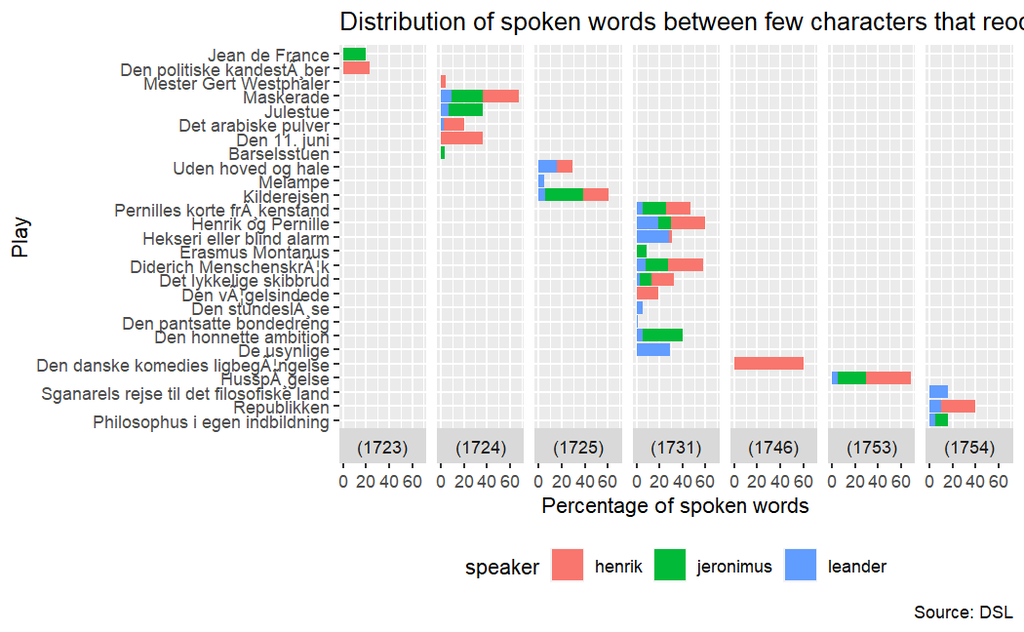

```r
summary %>%
  #filter(speaker %in% c("henrik","pernille","troels")) %>%
  filter(speaker %in%   c("henrik", "jeronimus", "leander")) %>%
  #arrange(year) %>%
  #mutate(title = str_c(title," ",year)) %>%
  ggplot(aes(fill = speaker, y = 100*freq, x = factor(title, factor_levels_sort_year))) +
    geom_bar(stat="identity") +
    theme(legend.position="bottom") +
    labs(
      title = "Distribution of spoken words between few characters that reoccur across Holberg's oeuvre by year of publication",
      #subtitle = toupper("TEST"),
      caption = "Source: DSL"
    ) +
  xlab("Play") +
  ylab("Percentage of spoken words") +
  facet_wrap(~year, ncol=nrow(summary), switch="x") +
  #theme(axis.text.x=element_blank()) +
  coord_flip()
      ggsave(here("graphs/pers-visualiseringer", "fordeling_talte_ord_flip_v2.pdf"), width=16, height=9)
```

## Diagram that is not divided by year

First, we should make a new assignment of sequence to the factors, since we want to include years.

```r
summary %>%
    ## filter(speaker %in%   c("henrik", "jeronimus", "leander")) %>%
    mutate(title_fct2 = str_c(title," ", year)) -> summary_with_yeartitle

summary_with_yeartitle %>%
    arrange(desc(year)) %>%
    distinct(title_fct2) %>%
    pull(title_fct2) -> factor_levels_2

factor_levels_2
```

```
 [1] "Philosophus i egen indbildning (1754)"
 [2] "Republikken (1754)"
 [3] "Sganarels rejse til det filosofiske land (1754)"
 [4] "Den forvandlede brudgom (1753)"
 [5] "HusspÃ¸gelse (1753)"
 [6] "Plutus (1753)"
 [7] "Den danske komedies ligbegÃ¦ngelse (1746)"
 [8] "Don Ranudo de Colibrados (1745)"
 [9] "De usynlige (1731)"
[10] "Den honnette ambition (1731)"
[11] "Den pantsatte bondedreng (1731)"
[12] "Den stundeslÃ¸se (1731)"
[13] "Den vÃ¦gelsindede (1731)"
[14] "Det lykkelige skibbrud (1731)"
[15] "Diderich MenschenskrÃ¦k (1731)"
```

[output cut: 22 more lines]

```r
summary_with_yeartitle %>%
    mutate(title_fct2 = factor(title_fct2, factor_levels_2)) -> summary_fct2

summary_fct2 %>% select(title_fct2)
```

| title_fct2 |
| --- |
| ARTAXERXES |
| ARTAXERXES |
| ARTAXERXES |
| ARTAXERXES |
| ARTAXERXES |
| ARTAXERXES |
| ARTAXERXES |
| ARTAXERXES |
| Barselsstuen (1724) |
| Barselsstuen (1724) |

[output cut: 603 more lines]

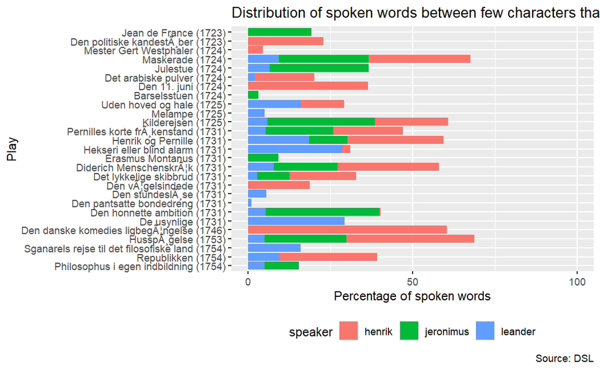

```r
summary_fct2 %>%
    ## filter(speaker %in% c("henrik","pernille","troels")) %>%
    filter(speaker %in%   c("henrik", "jeronimus", "leander")) %>%
    ggplot(aes(fill = speaker, y = 100*freq, x = title_fct2)) +
       geom_bar(stat="identity") +
       theme(legend.position="bottom") +
       labs(
           title = "Distribution of spoken words between few characters that reoccur across Holberg's oeuvre by year of publication",
           ## subtitle = toupper("TEST"),
           caption = "Source: DSL"
       ) +
    scale_y_continuous(limits = c(0,100), breaks = c(0,50,100)) +
    xlab("Play") +
    ylab("Percentage of spoken words") +
    coord_flip()
      ggsave(here("graphs/pers-visualiseringer", "fordeling_talte_ord_flip_v3.pdf"), width=16, height=9)
```

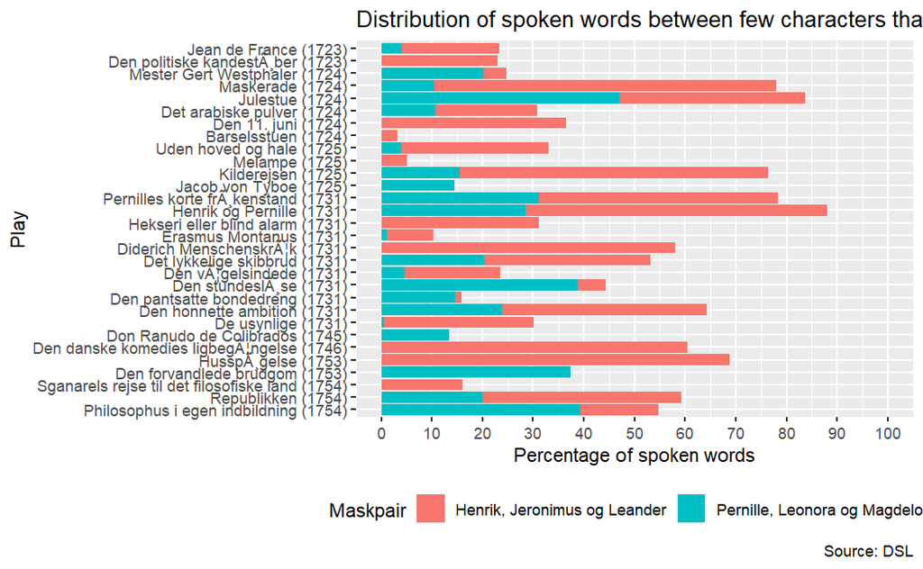

```r
group_1 <- c("henrik", "jeronimus", "leander")
group_2 <- c("pernille", "leonora", "magdelone")

summary_fct2 %>%
    filter(speaker %in% c(group_1, group_2)) %>%
    mutate(gruppe = if_else(speaker %in% group_1, "Henrik, Jeronimus og Leander","Pernille, Leonora og Magdelone")) %>%
    ## filter(speaker %in%   c("henrik", "jeronimus", "leander")) %>%
    ggplot(aes(fill = gruppe, y = 100*freq, x = title_fct2)) +
       geom_bar(stat="identity") +
       theme(legend.position="bottom") +
       labs(
           title = "Distribution of spoken words between few characters that reoccur across Holberg's oeuvre by year of publication",
           ## subtitle = toupper("TEST"),
           caption = "Source: DSL"
       ) +
    scale_y_continuous(limits = c(0,100), breaks = c(0,10,20,30,40,50,60,70,80,90,100)) +
    xlab("Play") +
    ylab("Percentage of spoken words") +
      labs(fill='Maskpair') +
    coord_flip()
      ggsave(here("graphs/pers-visualiseringer", "fordeling_talte_ord_flip_grupper.pdf"), width=16, height=9)
```